# Programming

“9. Statsmodels librray”

“Wen-Bin Chuang”

“2024/07/25”

# Today’s Topics

- Statsmodels librray
- Time Series
- Components and stationary
- ARIMA Model

# Introduction

Time-series data is a sequence of data points indexed in time order. It’s integral to many fields, from finance and economics to IoT and product development. Time series data provides a historical perspective, helping developers understand trends, patterns, and anomalies over time.

This type of data can be anything that changes over time, such as user activity logs, system metrics, or even the changing stock prices on a market. It’s a powerful tool for tracking changes, predicting future trends, or diagnosing issues.

Time-series analysis focuses on examining historical data to uncover patterns, trends, and other valuable insights. It is a crucial step in understanding the behavior of time-dependent data, Identifying data trends and patterns and making predictions for the future.

# **Decompose the Time Series Data**

A useful Python function called seasonal_decompose within the ‘statsmodels’ package can help us to decompose the data into four different components:

- Observed
- Trended
- Seasonal
- Residual

```python
# pip install statsmodels
import statsmodels.api as sm
# graphs to show seasonal_decompose
def seasonal_decompose (y):
    decomposition = sm.tsa.seasonal_decompose(y,
                                              model='additive',
                                              extrapolate_trend='freq')
    fig = decomposition.plot()
    fig.set_size_inches(14,7)
    plt.show()

seasonal_decompose(data)
```

[output not shown]

# **Stationarity**

Stationarity refers to a key concept in time-series analysis where the statistical properties of a dataset, such as mean and variance, remain constant over time.

In Python, testing for stationarity involves methods like the **Augmented Dickey-Fuller (ADF) test**, Kwiatkowski-Phillips-Schmidt-Shin (KPSS) test….

## Why does being stationary matter?

- **Time-series data spans time:** Time-series data is inherently temporal, capturing observations over a sequence of time intervals. For meaningful analysis, the statistical properties of the data must remain consistent over time. Such consistency allows analysts to draw reliable conclusions about the underlying processes driving the data and make informed decisions based on these insights. 資料具備一致性 才能進行推論
- **Simplicity in statistical analysis:** When the statistical properties of a time series vary with time, statistical analysis becomes challenging and complex. Inconsistencies in properties such as mean, variance, and autocorrelation can complicate modeling efforts and hinder interpretation. Stationarity simplifies the analysis by providing a stable framework where these properties remain constant over time. 資料裡的統計特性如果隨時間而變, 平均值, 變異數等就會成複雜 不易推論
- **Essential for projections and models:** Assuming some level of stationarity is crucial, particularly for projections and modeling purposes. By assuming stationarity, we can handle the noise in the data more effectively, leading to more reliable forecasts and model outcomes. 資料特性的固定才能處理裡而的雜訊.

## Background

A unit root in a time series refers to a characteristic of a stochastic process where the process has a root on the unit circle in the autoregressive polynomial. This implies that the time series is non-stationary, meaning its statistical properties such as mean and variance change over time.

In simpler terms, if a time series has a unit root, it suggests that shocks or changes to the series will have a permanent effect that the time series does not revert to a long-term mean and instead follows a trend.

## 1. Autoregressive Polynomial

For an autoregressive (AR) process, the relationship between current and past values of the time series can be described by an autoregressive polynomial.

$$\phi(B)y_t = \epsilon_t$$

$\epsilon$ is the white noise error term and

$$\phi\left(B\right)=1-\phi_{1}B-\phi_{2}B^{2}-...-\phi_{p}B^{p}$$

Here, B is the backshift operator such that $By_{t}=y_{t-1},B^{2}y_{t}=y_{t-2}$ and so on.

# ADF (Augmented Dickey-Fuller) Test

- **Null Hypothesis (H0):** The null hypothesis of the ADF test is that the time series has a unit root, meaning it is non-stationary.
- **Alternative Hypothesis (H1):** The alternative hypothesis is that the time series is stationary.

**p-value:** If the p-value is less than the significance level (e.g., 0.05), we reject the null hypothesis and conclude that the time series is stationary.

# Make Data Stationary

Many approaches to get stationarize data, but we’ll use de-trending, differencing, and then a combination of the two.

- Detrending
- Differencing
- Combining Detrending and Differencing

## Autocorrelation and partial autocorrelation

When working with time series data, it is often useful to analyze the autocorrelation of the data to understand the patterns and dependencies between time steps.

Two common tools for this analysis are the Autocorrelation Function (ACF) and the Partial Autocorrelation Function (PACF).

- The ACF plot shows the correlation of a time series with itself at different lags, while the PACF plot shows the correlation of a time series with itself at different lags, after removing the effects of the previous lags.
- ACF measures the relationship between a variable’s current and past values at different time lags. On the other hand, PACF quantifies the direct relationship between a variable’s current value and its past values, excluding the influence of intermediate-lagged variables.

Visualizing the ACF and PACF plots can give us the insights into the stationarity and the order of autoregressive (AR) and moving average (MA) components of a time series model.

- For a stationary series, the ACF should decay quickly, typically to zero. If the ACF tails off slowly or shows a strong pattern, it suggests that the time series might be non-stationary.
- For a stationary time series, the PACF plot should cut off after a few lags. If the PACF plot shows a significant number of lags with high values, it suggests the presence of non-stationarity.

If the ACF plot shows a **rapid decline** towards zero and the PACF plot cuts off quickly, the series is likely stationary. Actually, ACF slow decay can indicate a trend and repeating spikes suggest seasonal effects.

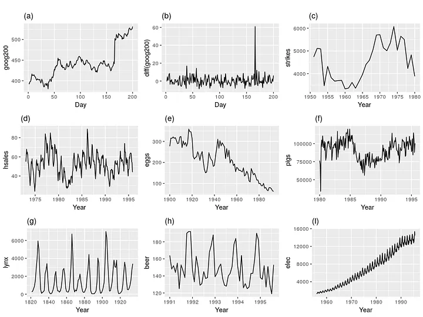

- Series (b) and (g) as the only stationary series.
- Prominent seasonality can be observed in series (d), (h) and (i).
- Noticeable trends and changing levels can be seen in series (a), (c), (e), (f) and (i).
- Series (i) shows increasing variance.

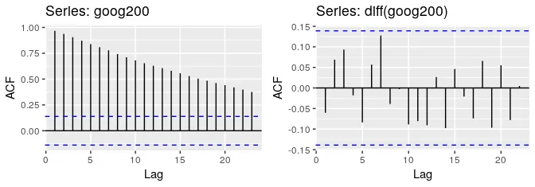

The values tend to degrade to zero quickly for stationary time series (see figure, right), while for non-stationary data the degradation will happen more slowly (see figure, left).

# **Forecast**

In time-series analysis, various forecasting models are available to predict future values based on historical data. Each model has its own strengths, limitations, and suitability for different types of time-series data.

- **Classical models**, such as ARIMA, SARIMA, Moving Averages, Exponential Smoothing, or Vector Autoregression.
- **Deep Learning models**, such as RNN, LSTM, or Transformers-based models.
- **Machine Learning models**, such as Linear Regression, Random Forest, and Gradient Boosting algorithms, like XGBoost and LightGBM, or any other regression algorithm.

# ARIMA (AutoRegressive Integrated Moving Average)

One popular method is the autoregressive integrated moving average (**ARIMA**) model. ARIMA is a powerful and widely used approach that combines the three following components to capture the patterns and trends in time-series data:

1. Autoregression (**AR**)
2. Differencing (**I**)
3. Moving Average (**MA**)

## Moving Average (MA)

The moving average model calculates the average of past observations to forecast future values. It helps eliminate short-term fluctuations and identify underlying trends in the data.

We can implement the moving average model using the `rolling` function in pandas, which calculates the mean over a specified window of past observations.

## Autoregressive (AR)

The autoregressive model predicts future values using past observations and a linear regression equation. It assumes that the future values depend on the previous values with a lag.

We can implement the autoregressive model using the `AR` class from the statsmodels library, which enables the fitting of an autoregressive model to the time-series data.

## Autoregressive Moving Average (ARMA)

The ARMA model combines the autoregressive and moving average models, making predictions based on past observations and the average of past errors.

We can implement the autoregressive moving average model using the `ARMA` class from the `statsmodels` library, which allows fitting an ARMA model to the time series data.

## Autoregressive Integrated Moving Average (ARIMA)

The ARIMA model extends the ARMA model by incorporating differencing to make the time series stationary. It is suitable for non-stationary data with trends and seasonality.

The autoregressive integrated moving average model can also be implemented using the `ARIMA` class from the `statsmodels` library.

## Other Model

- Seasonal ARIMA (SARIMA)
- Exponential Smoothing: Simple Exponential Smoothing (SES), Holt’s Linear Exponential Smoothing, and Holt-Winters Exponential Smoothing,…

Multiple parallel time series, e.g. multivariate time series

- Vector Autoregression (VAR)
- Vector Autoregression Moving-Average (VARMA)
- Vector Autoregression Moving-Average with Exogenous Regressors (VARMAX)